# NetPriori

CS4PPL

Ariel Salgado

27 de Julio de 2021

# Propuesta motivacional

El modelo propuesto en este notebook sirve para transformar una red de relaciones en una distribución de probabilidad *a priori* que vincule a las personas (los nodos de la red). Como problema *ad hoc* podemos pensar en una reunión a concretarse entre un grupo de amigues. La imagen es que existe una red que vincula la decisión de asistir al evento de las personas. En términos de DVI, podemos interpretar estas probabilidades como las de encontrar a las personas de interés en el *evento* (que puede ser un naufragio, una fosa común u otro). En general, podemos decir que el modelo aplica a la inferencia de quienes en un grupo de contactos optarán por una entre dos opciones.

# Formulación matemática

## Introducción

### Álgebra de escenarios

En lo que describiremos a continuación, trabajaremos con posibles escenarios y sus probabilidades. Bajo el riesgo de abusar levemente de la notación, asociaremos el símbolo $1$ a la sentencia *la persona 1 está en el evento*, y el síbolo $\bar 1$ a la negación de la sentencia anterior, es decir: *la persona 1 no está en el evento*. En general, para la persona $r$ usaremos la notación $r$ y $\bar r$ para indicar si está o no en el evento. Notese que cada una de estas sentencias es dicotómica, por lo que $r+\bar r$ siempre será verdad (la persona está ó no está en el evento). Al considerar una persona más, nuestro universo de opciones duplica en tamaño. Si pensamos en 2 personas, tendremos los escenarios posibles:

- $12$ (ambas están en el evento)
- $1 \bar 2$ (sólo la 1 está en el evento)
- $\bar 1 2$ (sólo la 2 está en el evento)
- $\bar 1 \bar 2$ (ninguna está en el evento)

Cuando pensamos la probabilidad de cada escenario posible, podemos identificar cada escenario como la realización de una distribución multinomial, donde los parámetros que definen la distribución son las probabilidades de cada escenario (y sólo se saca una realización, el escenario observado). Entonces, manteniendo nuestra ejemplo de dos personas, tendríamos las probabilidades $\theta_{12}$ asociada al escenario $12$, $\theta_{1 \bar 2}$ asociada al escenario $1 \bar 2$, $\theta_{\bar 1 2}$ para $\bar 1 2$ y $\theta_{\bar 1 \bar 2}$ para $\bar 1 \bar 2$. Sin embargo, estos parámetros no son independientes, al igual que los valores de verdad de los escenarios. Dado que

$$12 + 1 \bar 2 + \bar 1 2 + \bar 1 \bar 2 = \text{TRUE}$$
ya que necesariamente uno de los escenarios debe ser el correcto, también tenemos que

$$\theta_{12} + \theta_{ 1 \bar 2} + \theta_{\bar 1 2} + \theta_{\bar 1 \bar 2} = 1$$
Es decir que una de las probabilidades puede ser hallada en función de las otras. Más aún, la probabilidad de que la persona 1 participe del evento (sentencia que escribimos como $1$) la podemos calcular como

$$\begin{align}
P(1) &= P(1(2+\bar 2)) = P(12 + 1 \bar 2) \\&= P(12) + P(1 \bar 2) = \theta_{12} + \theta_{1 \bar 2} \\ &= \theta_{1}
\end{align}$$
Donde en el último paso definimos $\theta_1=P(1)$ y lo vinculamos con los otros $\theta$.

Consideremos ahora tres problemas separados.

- Sí sólo tuviesemos una persona en solitario, nuestra distribución de probabilidades estaría dada por $\theta_1$ y $\theta_{\bar 1} = 1 -\theta_1$
- Si tuvieramos dos personas ya vimos que nuestra distribución de probabilidades queda definida por $\theta_{12}$, $\theta_{1 \bar 2}$, $\theta_{\bar 1 2}$ y $\theta_{\bar 1 \bar 2} = 1- (\theta_{12} + \theta_{1 \bar 2}+\theta_{\bar 1 2})$. Sin embargo, si agregamos la suposición adicional de que ambos son independientes tendríamos que $P(12)=P(1)P(2)=\theta_1 \theta_2$ y entonces nuestro número de parámetros se reduce a 2.
- Si tuvieramos tres personas, pero la tercera es independiente de las otras dos, nuestro problema matemático se partiría en dos: uno que habla de las personas 1 y 2, y que requeriría especificar una distribución $\theta_{12},\theta_{1 \bar 2},...$ y otro para la persona 3 que requeriría especifica $\theta_3$. Luego las probabilidades se escribirían por ejemplo como $P(1 \bar 2 \bar 3) = P(1 \bar 2) P(\bar 3) = \theta_{1 \bar 2} (1- \theta_3)$.

### La red

Lo presentado hasta aquí nos permite formalizar distintos escenarios que conecten uno o varios grupos de personas. Sin embargo, nuestro objetivo es construir un modelo que nos permita convertir información de una red en información sobre la forma en la que debemos elegir los parámetros que la representen. Veamos algunos ejemplos:

```r
require(igraph)
par(mfrow=c(1,3))
make_empty_graph(n=3,directed=FALSE) %>% plot()
make_empty_graph(n=3,directed=FALSE) %>% add_edges(edges=c(1,2,1,3,2,3))%>% plot()
```

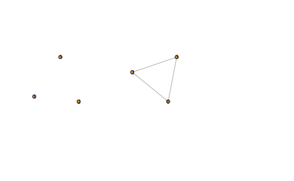

```r
make_empty_graph(n=3,directed=FALSE) %>% add_edges(edges=c(1,2,1,3))%>% plot()
```

[output not shown]

- La red de la izquierda corresponde a una situación en la cual no hay relación entre ninguno de los nodos. Entonces, la distribución de probabilidad apropiada sería una en la que todos los nodos son independientes: $P(r)=\theta_r$, y $P(123) = \theta_1 \theta_2 \theta_3$.
- Las redes del centro y de la derecha require un poco más de cuidado.
- La red del centro tiene dos interpretaciones posibles. Una sería pensar que al estar todos conectados entre todos, con lo cual nuestra distribución sería la conjunta completa $(\theta_{123},\dots,\theta_{\bar 1 \bar 2 \bar 3})$. Aún así, podemos simplificar esto bajo ciertos supuestos, que veremos más adelante.
- La red de la derecha, por el contrario, vincula a los tres nodos, pero no de forma simétrica. Mientras que la persona 2 no está conectada a la 3 directamente, ambas se conectan con la 1. Esto nos sugiere que considerar directamente la distribución conjunta completa podría ser excesivo.

La conclusión que extraemos de estos tres ejemplos es:

- Cuando las personas están desconectadas *completamente* (no existen caminos entre ellas), tiene sentido pensarlas como *independientes*.
- Cuando hay conexiones entre las personas, parece sensato más que pensar en el grupo completo directamente, pensar las correlaciones de a pares. Esto tiene sentido porque bajo la apariencia de la red las conexiones entre las personas siempre son de a pares. Pensandolo *condicionalmente*, lo que estaríamos diciendo es que para estudiar $P(2|3)$ en una red como la del gráfico de la derecha, tendríamos que pensar en $P(2|1)$ y en $P(1|3)$, siendo: $P(2|3) = P(21|3) + P(2 \bar 1|3) = P(2 | 13) P(1|3) + P(2|\bar1 3)P(\bar 1 |3) = P(2|1)P(1|3) + P(2|\bar 1)P(\bar 1|3)$. Es decir, condicionando bajo $1$, $3$ es irrelevante para la probabilidad de $2$.

Dado que los escenarios ocurren una única vez, la estimación de los $\theta$ debemos hacerla en base a otra información. A continuación, lo que proponemos es usar la estructura de la red para construir una distribución *a priori* sobre los $\theta$ que nos permita representar las conexiones que esta representa, sin darnos información específica sobre si las personas van a estar o no en el evento.

Para construir nuestra priori sobre los $\theta$ vamos a seguir dos pasos:

- El primero consiste en definir cuál es la distribución de probabilidad que representa una red que consista de dos personas conectadas por un link. Dado que los links serán nuestra unidad fundamental, necesitamos tener caracterizado qué información nos da cada uno.
- El segundo consiste en definir como combinar distintos links. Las redes del gráfico anterior nos sugieren que si bien tiene sentido pensar las probabilidades en términos de los links, la información de un nodo debería afectar a los otros a través de las conexiones que hay entre ambos.

### Notación

En todo momento estaremos pensando en las probabilidades de que ocurran los escenarios. Ya mencionamos que notaremos un escenario $rs$, que significa que la persona r y la persona s ambas están presentes en el evento. También ya mostramos que para cada escenario que involucre a un subconjunto de personas, tenemos un espacio muestral completo, en el sentido de que $rs + \bar r s + r \bar s + \bar r \bar s = 1$, dado que necesariamente alguna de estas situaciones debe ser cierta. Este concepto vale por igual al ampliar el número de personas. Además, vimos que podemos marginalizar sobre escenarios, de forma que, por ejemplo $rs = rsq + rs \bar q$, gracias a que $q + \bar q = 1$. Las probabilidades las notamos con la letra $\theta$, donde $P(rs) = \theta_{rs}$. De las relaciones entre los escenarios se sigue que

$$\theta_{rs} + \theta_{r \bar s} + \theta_{\bar r s} + \theta_{\bar r \bar s} = 1$$
y que
$$\theta_{rs} = \theta_{rsq} + \theta_{rs\bar q}$$

Para ahorra espacio, llamaremos $z_{rs}=(\theta_{rs},\theta_{r \bar s},\theta_{\bar r s})$, que es el vector que nos representa las tres probabilidades necesarias para definir las probabilidades de los eventos que sólo involucren a las personas r y s.

### Un sólo link

Exploremos cómo podemos representar la información que nos da una conexión única en la red. Para este ejemplo pensaremos que sólo tenemos dos personas 1 y 2. Ya vimos que personas desconectadas de estas serán independientes, por lo que no cambiarán nada en la distribución de probabilidad. Por otro lado, combinaciones de links será lo que nos ocupará más adelante.

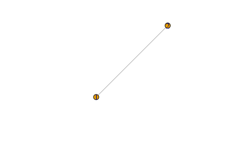

```r
require(igraph)
make_empty_graph(n=2,directed=FALSE) %>% add_edges(edges = c(1,2)) %>% plot()
```

Partimos de que tenemos que definir tres valores $\theta_{12},\theta_{1 \bar 2}, \theta_{\bar 1 2}$ para definir la distribución de probabilidad de estas dos personas. Nuestro objetivo no es definir exactamente estos valores, sino dar una distribución de probabilidad que represente los posibles valores que pueden tomar. Por esta razón, una distribución de Dirichlet es lo más razonable para describirlos. La distribución de Dirichlet es la conjugada de la multinomial, y cumple con los requerimientos que pedimos para los parámetros: todos los $\theta$ deben ser mayores a cero y menores a uno, y deben sumar uno al considerar los cuatro escenarios posibles. Para definir la distribución de Dirchlet, necesitamos definir en principio cuatro parámetros $\kappa_{12}$,$\kappa_{1 \bar 2}$,$\kappa_{\bar 1 2}$ y $\kappa_{\bar 1 \bar 2}$ que comandan los valores esperados y la varianza de cada uno de los $\theta$. Necesitaremos definir también $\kappa = \kappa_{12}+\kappa_{1 \bar 2}+ \kappa_{\bar 1 2}+\kappa_{\bar 1 \bar 2}$. Una distribución de Dirichlet tiene la pinta:

$$f(z_{12}|\kappa_{12},\kappa_{1 \bar 2}, \kappa_{\bar 1 2},\kappa_{\bar 1 \bar 2}) = \frac{\Gamma(\kappa)}{\Gamma(\kappa_{12}) \Gamma(\kappa_{1 \bar 2}) \Gamma(\kappa_{\bar 1 2}) \Gamma(\kappa_{\bar 1 \bar 2})} \theta_{12}^{\kappa_{12}-1} \theta_{1 \bar 2}^{\kappa_{1\bar 2}-1} \theta_{\bar 1 2}^{\kappa_{\bar 1 2}-1} (1-\theta_{12}-\theta_{1 \bar 2}-\theta_{\bar 1 2})^{\kappa_{\bar 1 \bar 2}-1}$$
donde $\Gamma$ es la función gamma, similar al factorial.

Para lo que sigue es útil tener presente también que

$$E[\theta_{rs}] = \frac{\kappa_{rs}}{\kappa}$$

Al considerar la suma de dos de los $\theta_{rs}$ (es decir agregar sobre un subconjunto de posibilidades) lo que obtenemos es una distribución de Dirichlet, con los valores de $\kappa_{rs}$ sumados. De esta forma, si consideramos $\theta_1 = \theta_{12} + \theta_{1 \bar 2}$, la probabilidad marginal de encontrar a la persona 1, y $\theta_2 = \theta_{1 2} + \theta_{\bar 1 2}$ la probabilidad de encontrar a la persona 2 en el evento, tenemos que:

$$\theta_1 \sim Beta(\kappa_{12} + \kappa_{1 \bar 2},\kappa_{\bar1 2} + \kappa_{\bar 1 \bar 2})$$

$$\theta_2 \sim Beta(\kappa_{12} + \kappa_{\bar 1 2},\kappa_{1 \bar 2} + \kappa_{\bar 1 \bar 2})$$
(recordar que la distribución Beta es una Dirichlet con sólo dos parámetros).

Con todo esta estructura definida, lo que queremos es elegir los parámetros de la distribución para que representen lo que intuímos a partir de los links. Lo que interpretamos que representa un link es que es más probable que las personas a sus extremos tengan participen del igual forma del evento. Es decir, es más probable $\theta_{12}$ y $\theta_{\bar 1 \bar 2}$ (ambas personas participan o no del evento) que $\theta_{1 \bar 2}$ y $\theta_{1 \bar 2}$ (sólo participa del evento una de las personas). Matemáticamente, representamos esto a través de una relación entre los valores esperados de los $\theta$. Definimos a $\gamma$ como la cantidad de veces más probable que es encontrar juntas a las personas que separadas:

$$\gamma = \frac{E[\theta_{12} + \theta_{\bar 1 \bar 2}]}{E[\theta_{1\bar 2} + \theta_{ 1 \bar 2}]} = \frac{\kappa_{12} + \kappa_{\bar 1 \bar 2}}{\kappa_{\bar1 2} + \kappa_{ 1 \bar 2}}$$

Por otro lado, considerando el hecho de que las distribuciones de $\theta_1$ y $\theta_2$ son Betas, querríamos que estas no provean información ni afirmativa ni negativa sobre las posibilidades de encontrar a las personas en el evento (esta información debería provenir de otra fuente que no sea la red). Por lo tanto obtenemos las tres ecuaciones. Podemos interpretar el hecho de que las distribuciones de $\theta_1$ y $\theta_2$ no nos ayuden a afirmar ni a negar que las personas van a estar o no en el evento como pedir que $E[\theta_1] = E[\theta_2]=0.5$. Esto dice que nuestra expectativa sobre sus valores es que sean 0.5. Que estén o no en el evento es igualmente probable. Esto se traduce en una condición sobre los exponentes de las Betas, que deben ser iguales. De esta forma, tenemos tres ecuaciones que representan lo que propusimos sobre el sistema:

$$\begin{eqnarray}
\kappa_{12} - \gamma \kappa_{1\bar2}-\gamma \kappa_{\bar 1 2} + \kappa_{\bar 1 \bar 2} = 0\\
\kappa_{12} + \kappa_{1 \bar 2} - \kappa_{\bar 1 2} -\kappa_{\bar 1 \bar 2} = 0 \\
\kappa_{12} - \kappa_{1 \bar 2} + \kappa_{\bar 12} -\kappa_{\bar 1 \bar 2} = 0
\end{eqnarray}$$

La primer ecuación es la relación impuesta por $\gamma$, y las otras dos salen de pedir que las esperanzas de los $\theta_1$ y $\theta_2$ sean iguales a 0.5.

Despejando estas ecuaciones llegamos a que

$$\begin{align}
\kappa_{1 \bar 2} = \kappa_{\bar 1 2}\\
\kappa_{12} = \kappa_{\bar 1 \bar 2}\\
\kappa_{1 \bar 2} = \frac{1}{\gamma} \kappa_{12}
\end{align}$$
Si usamos como parámetros de control de la distribución a $\gamma$ y a $\kappa$, tendremos que $\kappa = \frac{2}{\gamma} \kappa_{12} + 2 \kappa_{12} = 2 \frac{\gamma+1}{\gamma } \kappa_{12}$ y por lo tanto

$$\begin{eqnarray}
\kappa_{12} = \kappa_{\bar 1 \bar 2} = \frac{\gamma}{2(\gamma +1 )} \kappa \\
\kappa_{1 \bar 2} = \kappa_{\bar 1 2} = \frac{1}{2(\gamma +1 )} \kappa \\
\end{eqnarray}$$
Vemos que bajo estas condiciones, la esperanza $\theta_{rs} = \kappa_{rs}/\kappa$ sólo depende de $\gamma$, variando entre $0$ y $+\infty$ para $12,\bar 1 \bar 2$, y a la inversa para $1 \bar 2,\bar 1 2$. Con estos valores, tenemos

$$\begin{eqnarray}
\kappa_1 = \kappa_{12} + \kappa_{1 \bar 2} = \frac{\gamma+1}{2(\gamma +1 )} \kappa = \frac{1}{2} \kappa \\
\kappa_2 = \kappa_1 = \frac{1}{2} \kappa \\
\end{eqnarray}$$

El parámetro $\kappa$ comanda la varianza del sistema. Por ejemplo, para los $\theta_1,\theta_2$, su varianza está dada por

$$V[\theta_1] = V[\theta_2] = \frac{1}{4(\kappa+1)}$$

Entonces, para definir nuestro modelo del link necesitamos especificar dos parámetros: $\gamma$ y $\kappa$, que dictan la esperanza y la varianza del sistema. Para resumir, llamaos a $w_{12} = (\gamma,\kappa)$, que nos permite definir las distribuciones completamente.

$$f(z_{12}|w_{12}) = \frac{\Gamma(\kappa)}{[\Gamma(\frac{\gamma \kappa}{2(\gamma+1)}) \Gamma(\frac{ \kappa}{2(\gamma+1)})]^2}
\theta_{12}^{\frac{\gamma \kappa}{2(\gamma+1)}-1} \theta_{1 \bar 2}^{\frac{ \kappa}{2(\gamma+1)}-1} \theta_{\bar 1 2}^{\frac{ \kappa}{2(\gamma+1)}-1} (1-\theta_{12}-\theta_{1 \bar 2}-\theta_{\bar 1 2})^{\frac{\gamma \kappa}{2(\gamma+1)}-1}$$

Mientras que para $\theta_r$ tendremos:

$$f(\theta_r|w_{12}) = \frac{\Gamma(\kappa)}{\Gamma(\kappa/2)^2} \theta_r^{\kappa/2-1} (1-\theta_r)^{\kappa/2-1}$$

Veamos un poco qué pinta tienen estas distribuciones. Para ejemplificar elegimos $\gamma=10$ y $\kappa=22$, de forma tal que $\kappa_{12}=\kappa_{\bar 1 \bar 2} = 10$ y $\kappa_{1 \bar 2} = \kappa_{\bar 1 2}=1$. Las esperanzas son $E[z_{12}] = (0.45,0.05,0.05)$. Como mencionamos antes, $E[\theta_r] = 1/2$ y $\sqrt{V[\theta_r]} = 0.1$ es su desviación estandar.

En los gráficos que siguen, la notación usada es $\theta_{12}$=`t12`, $\theta_{1 \bar 2}$=`t1n2`, $\theta_{\bar 1 2}$ =`tn12` y $\theta_{\bar 1 \bar 2}$=`tn1n2`.

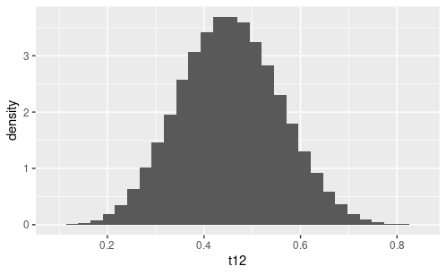

```r
require(MCMCpack)
require(ggplot2)
require(patchwork)
gamma=10
kappa=22
kappas = c(gamma,1,1,gamma)*kappa/(2*(gamma+1))
muestras = rdirichlet(n=1e5,kappas)

df = data.frame(muestras)
colnames(df) = c('t12','t1n2','tn12','tn1n2')
gg12 = ggplot(data=df,aes(x=t12,y=..density..)) + geom_histogram()
gg1n2 = ggplot(data=df,aes(x=t1n2,y=..density..)) + geom_histogram()
gg12_1n2 = ggplot(data=df,aes(x=t12,y=t1n2)) + geom_bin2d()
gg12_n1n2 = ggplot(data=df,aes(x=t12,y=tn1n2)) + geom_bin2d()
gg1n2_n12 = ggplot(data=df,aes(x=tn12,y=t1n2)) + geom_bin2d()
gg1 = ggplot(data=df,aes(x=t12+t1n2,y=..density..)) + geom_histogram()
gg2 = ggplot(data=df,aes(x=t12+tn12,y=..density..)) + geom_histogram()
gg1_2 = ggplot(data=df,aes(x=t12+t1n2,y=t12+tn12)) + geom_bin2d()

print(gg12)
```

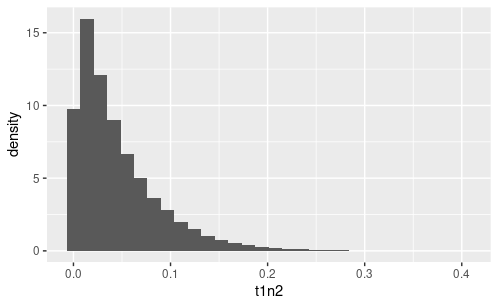

```r
print(gg1n2)
```

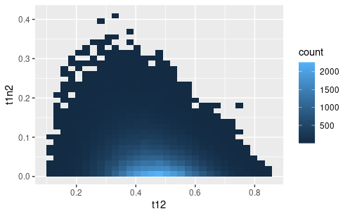

```r
print(gg12_1n2)
```

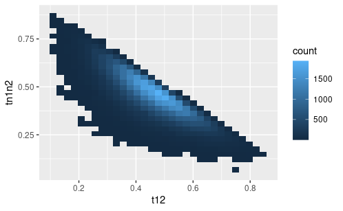

```r
print(gg12_n1n2)
```

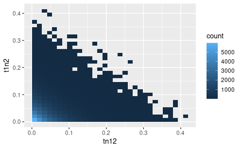

```r
print(gg1n2_n12)
```

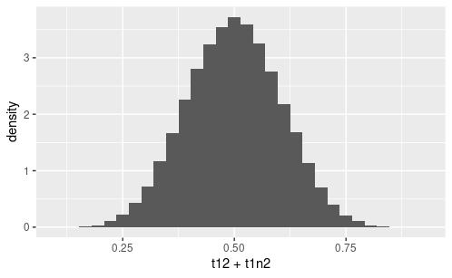

```r
print(gg1)
```

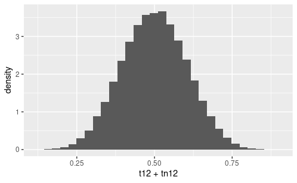

```r
print(gg2)
```

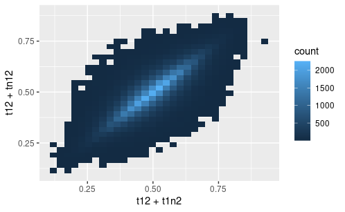

```r
print(gg1_2)
```

Vemos que con estos valores las distribuciones de $\theta_{12}$ y $\theta_{\bar 1 \bar 2}$ (representadas a través de `t12`, recuerden que ambas distribuciones son iguales), están concentradas en 0.45, con una varianza bastante amplia. Por otro lado, la distribución de $\theta_{1 \bar 2}$ y $\theta_{\bar 1 2}$ están concentradas cerca de cero. Graficando $\theta_{12}$ vs $\theta_{ 1 \bar 2}$ vemos una distribución que para valores altos de $\theta_{1 \bar 2}$ indica valores más bajos de $\theta_{12}$, pero que tiene el grueso de su masa concentrada en (0.45,0.05), donde está las esperanzas de ambas variables. Graficando $\theta_{12}$ contra $\theta_{\bar 1 \bar 2}$ vemos que la distribución está concentrada sobre la recta $\theta_{12}+\theta_{\bar 1 \bar 2}=1$, aunque el grueso de la distribución está en (0.45,0.45). Algo similar ocurre para $\theta_{1 \bar 2}$ vs $\theta_{\bar 1 2}$, aunque aquí el grueso de la distribución se concentra en (0.05,0.05). Las distribuciones de $\theta_1$ y $\theta_2$ se centran en 0.5. Graficando una en función de la otra vemos que están fuertemente correlacionadas.

#### $\gamma$ y $\kappa$

$\gamma$ y $\kappa$ deberían ser elegidos para representar la información que posee sobre la red quien la usa. Sin embargo, es útil entender cómo varian las distribuciones al variar sus valores.

Teniendo en cuenta que la esperanza de los $\theta$ está completamente dada por $\gamma$, y que $E[\theta_{12} ] = E[\theta_{\bar 1 \bar 2}]$ y $E[\theta_{1 \bar 2} ] = E[\theta_{\bar 1 2}]$ entonces podemos graficar uno en función del otro:

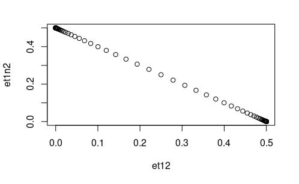

```r
gamma = 10**(seq(-10,10,.1))
et12 = gamma/(2*(gamma+1))
et1n2 = 1/(2*(gamma+1))
plot(et12,et1n2)
```

La relación entre ambos es lineal, moviendose de $E[\theta_{12}] = 0.5$ cuando $\gamma\rightarrow +\infty$ a $E[\theta_{12}] = 0$ cuando $\gamma \rightarrow 0$

Por otro lado, el parámetro $\kappa$ mide la varianza del sistema, a $\gamma$ fijo. En particular, en los $\theta_r$ es casi la inversa de la varianza

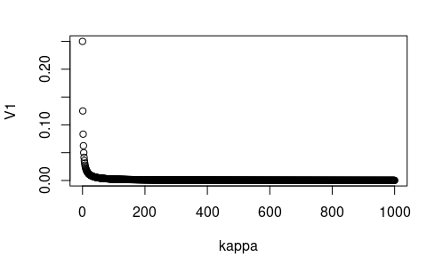

```r
kappa = seq(0,1e3,1)
V1 = 1/(4*(kappa+1))
plot(kappa,V1)
```

Cuando pensamos en las otras variables, vemos que tendremos dos varianzas distintas:

$$V[\theta_{12}] = \frac{\gamma (\gamma +2) }{4(\gamma+1)^2} \frac{1}{\kappa +1}$$

$$V[\theta_{1 \bar 2}] = \frac{(2\gamma +1) }{4(\gamma+1)^2} \frac{1}{\kappa +1}$$

Para $\kappa$ fijo, $V[\theta_{12}] \rightarrow \frac{1}{4(\kappa+1)}$ y $V[\theta_{1 \bar 2}] \rightarrow 0$ cuando $\gamma \rightarrow +\infty$. En $\gamma=0$ ocurre la situación inversa.

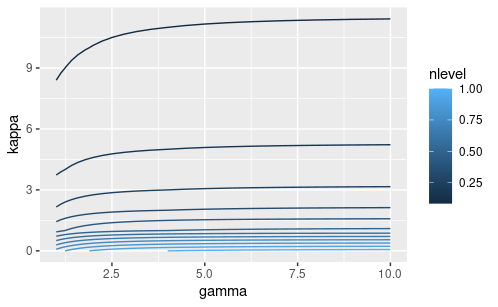

```r
require(ggplot2)
gammas = 10**seq(0,1,.05)
kappas = seq(0,50,1)
V12f = function(gamma,kappa) gamma*(gamma+2)/(2*(gamma+1))**2/(kappa+1)
E12f = function(gamma,kappa) gamma/(2*(gamma+1))
df = expand.grid('gamma'=gammas,'kappa'=kappas)
df$V12 = V12f(df$gamma,df$kappa)
df$E12 = E12f(df$gamma,df$kappa)
ggplot(data=df,mapping=aes(x=gamma,y=kappa,z=V12,fill=E12)) + geom_contour(aes(colour = after_stat(nlevel)))
```

Este gráfico nos muestra que podemos ir aumentando los valores de $\gamma$ y $\kappa$ conjuntamente para lograr mantener la varianza constante.

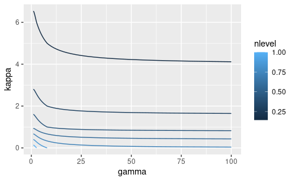

```r
require(ggplot2)
gammas = 10**seq(0,2,.05)
kappas = seq(0,100,1)
V12f = function(gamma,kappa) gamma*(gamma+2)/(2*(gamma+1))**2/(kappa+1)
V1n2f = function(gamma,kappa) (2*gamma+1)/(2*(gamma+1))**2/(kappa+1)

df = expand.grid('gamma'=gammas,'kappa'=kappas)
df$VS = 2*V12f(df$gamma,df$kappa)+2*V1n2f(df$gamma,df$kappa)

ggplot(data=df,mapping=aes(x=gamma,y=kappa,z=VS)) + geom_contour(aes(colour = after_stat(nlevel)))
```

Calculando la varianza “total” del sistema (la suma de las 4 varianzas) lo que encontramos es una curva que se repite para todos los valores de $\kappa$. Mientras que el decaimiento de esta curva está dado por $\gamma$, el offset al que ocurre está dado por $\kappa$.

```r
entropy_dir = function(gamma,kappa){
  g = base::gamma
  dg = base::digamma
  a = 2*(gamma+1)
  lB = -log(g(kappa))+2*(log(g(gamma/a*kappa))+log(g(kappa/a)))
  phi = (kappa-4)*dg(kappa)
  phi2 = 2*(gamma/a*kappa-1)*dg(gamma/a*kappa) + 2*(kappa/a-1)*dg(kappa/a)
  H = lB + phi-phi2
  return(H)
}
gammas = 10**seq(0,3,.05)
kappas = seq(0,200,1)
df = expand.grid('gamma'=gammas,'kappa'=kappas)
df$H = entropy_dir(df$gamma,df$kappa)
```

```
NaNs producedNaNs producedNaNs producedNaNs producedNaNs producedNaNs produced
```

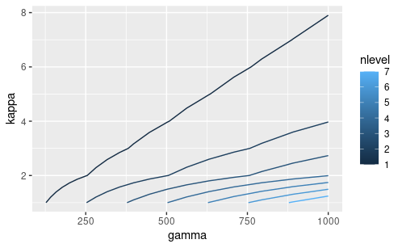

```r
ggplot(data=df,mapping=aes(x=gamma,y=kappa,z=H)) + geom_contour(aes(colour = after_stat(nlevel)))
```

```r
entropy_dir(1e3,2)
```

```
[1] -1988.179
```

```r
entropy_dir(250,2)
```

```
[1] -490.9361
```

De estas gráficas podemos concluir que podemos fijar una magnitud que sea interpretable, por ejemplo la varianza total, y fijarla en un dado valor $V_0$. Entonces, podremos encontrar una curva que de $\kappa$ en función de $\gamma$.

### Conclusiones

Vimos cómo construir la distribución de probabilidad de un link. Esto se realiza a través de una Dirichlet que tiene dos parámetros a definir, $\gamma$ que representa cuanto más creible es el escenario “en conjunto” que el escenario “por separado”; y $\kappa$ que mide la variabilidad en el sistema completo. Cuando consideremos un link que une a las personas r y s, llamaremos a la función que obtuvimos $f_{rs}(z_{rs}|w_{rs})$, o simplemente $f_{rs}(z_{rs})$ o $f_{rs}$ según se sobre entienda o no los argumentos y parámentros en cada caso.

## Considerando varios links

Habiendo definido forma funcional para la distribución de un link, ahora nuestra siguiente cuestión es cómo extender esa estructura a un conjunto de links. Lo haremos analizando ejemplos de complejidad incremental.

### Dos links separados

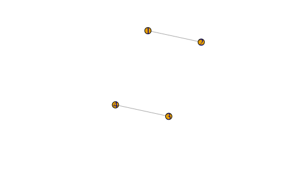

```r
require(igraph)
make_empty_graph(n=4,directed=FALSE) %>% add_edges(edges = c(1,2,3,4)) %>% plot()
```

Si bien en sí no es muy interesante, es útil para motivar el paso siguiente. Consideremos qué podríamos decir de dos links separados. Dado que estos dos links no conectan nodos en común, la densidad conjunta sería simplemente el producto de las densidades.

Si $f_{12}$ es la densidad asociada a considerar el link de las personas $1$ y $2$, y $f_{34}$ lo mismo para $3$ y $4$, entonces tendríamos que

$$f_{12,34}(z_{12},z_{13}) = f_{12}(z_{12}) \cdot f_{34}(z_{34})$$
donde $f_{12,34}$ representa la densidad conjunta de $z_{12}$ y $z_{34}$. Al no existir correlación entre ambas simplemente se multiplican entre sí. Agregando un poco más de notación, llamaremos $z$ al concatenado de los $z_{rs}$. En este caso, $z=(z_{12},z_{34}) = (\theta_{12},\theta_{1\bar 2},\theta_{\bar 1 2},\theta_{3 4},\theta_{3\bar 4},\theta_{\bar 3 4})$.

### Un nodo con dos links

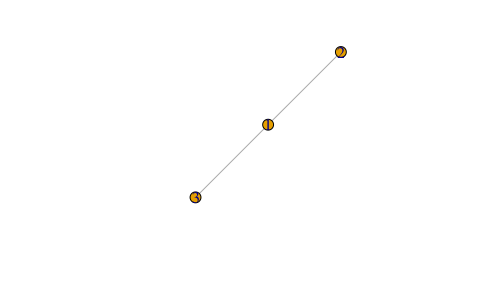

```r
require(igraph)
make_empty_graph(n=3,directed=FALSE) %>% add_edges(edges = c(1,2,1,3)) %>% plot()
```

En este ejemplo, tenemos un vértice, en el cual la persona 1 está conectada a la 2 y a la 3, pero la 2 y la 3 no se conectan entre sí. Como mencionamos previamente, podríamos pensar este problema a través de una densidad conjunta de a tres: $\theta_{123},\theta_{12\bar 3},\dots,\theta_{\bar 1 \bar 2 \bar 3}$. El problema es que definir razonablemente esta densidad requeriría tener en claro por ejemplo, la diferencia en lo que esperamos de $\theta_{123}$ y $\theta_{12 \bar 3}$. Como la red sólo nos muestra relaciones de a pares, no es claro como representar esto.

La propuesta en cambio es continuar trabajar a través de los parámetros que pudimos asociar a los links. En este caso, $z_{12}$ y $z_{13}$. El tema es que claramente estos dos vectores no son independientes. A diferencia de lo que ocurría con $z_{12}$ y $z_{34}$ en el ejemplo anterior, que no estaba conectados, en este caso tenemos una conexión a través de la persona 1. Si pensamos que lo que comanda todo al final es una distribución $\theta_{123},\theta_{12\bar 3},\dots,\theta_{\bar 1 \bar 2 \bar 3}$ asociada a los 8 escenarios posibles $123, 12 \bar 3, \dots, \bar 1 \bar 2 \bar 3$, tenemos que

$$\begin{align}
\theta_{12} = \theta_{123} + \theta_{12 \bar 3} \\
\theta_{1 \bar 2} = \theta_{1 \bar 2 3} + \theta_{1 \bar2 \bar 3} \\
\theta_{13} = \theta_{123} + \theta_{1 \bar 2 3} \\
\theta_{1 \bar 3} = \theta_{1 2 \bar 3} + \theta_{1 \bar2 \bar 3} \\
\dots
\end{align}$$

Con relaciones similares para el resto de los parámetros. Más aún,

$$\begin{align}
\theta_1 &= \\
&= \theta_{123} + \theta_{12 \bar 3} + \theta_{1 \bar 2 3 } + \theta_{1 \bar 2 \bar 3} \\
&= \theta_{13} + \theta_{1 \bar 3} \\
\rightarrow \theta_{12} + \theta_{1 \bar 2} &= \theta_{13} + \theta_{1 \bar 3}
\end{align}$$

Esta relación impone un vínculo entre las dos distribuciones marginales, y resta una dimensión al problema: pasamos de tener 6 parámetros a definir, a tener 5. Matemáticamente, esta relación de vínculo puede representarse en la densidad escribiendola con una delta de Dirac, que asigne valor cero a los valores fuera del vínculo. Incorporando eso a nuestra propuesta de $f_{12,13}$ tendremos que

$$f_{12,13}(z_{12},z_{13}) = f_{12}(z_{12}) \cdot f_{13}(z_{13}) \cdot \delta(\theta_{1 2} + \theta_{1 \bar 2} - \theta_{1 3} - \theta_{1 \bar 3})$$
La delta de Dirac vale infinito sobre el vínculo, lo que permite que marginalicemos sobre el mismo reduciendo la dimensión del problema.

Si bien esto formalmente es muy simpático, desde una perspectiva práctica no nos permite avanzar mucho. Por otro lado, las ecuaciones con las que estamos trabajando son lineales. Eso nos permite encontrar una forma de escribir los $\theta$ de forma que cumplan automáticamente el vínculo. Para esto, volvamos sobre el vector $z = (z_{12},z_{13}) = (\theta_{12},\theta_{1 \bar 2},\theta_{\bar 1 2},\theta_{13},\theta_{1 \bar 3},\theta_{\bar 1 3})$

Si nuestra condición de vínculo está representada por una matriz $A$ tal que $Az=0$, tenemos que $A=(1,1,0,-1,-1,0)$. Los vectores $\tilde z$ que cumplen con la condición de vínculo son aquellos que están en el núcleo de $A$. Usando MASS podemos calcular el núcleo fácilmente.

```r
require(MASS)
A= c(1,1,0,-1,-1,0)
fractions(Null(A))
```

```
     [,1] [,2] [,3] [,4] [,5]
[1,] -1/2    0  1/2  1/2    0
[2,]  5/6    0  1/6  1/6    0
[3,]    0    1    0    0    0
[4,]  1/6    0  5/6 -1/6    0
[5,]  1/6    0 -1/6  5/6    0
[6,]    0    0    0    0    1
```

Las 5 columnas de esta matriz representan los 5 vectores ortogonales $v_1,\dots,v_5$ tales que cualquier combinación lineal de ellos cumple la condición impuesta. Notemos que la condición de vínculo nos conecta los valores de $\theta_{12},\theta_{1 \bar 2}, \theta_{1 3}, \theta_{1 \bar 3}$, pero deja liberados a $\theta_{\bar 1 2},\theta_{\bar 1 3}$. Esto se manifiesta en que la segunda y la quinta columna del núcleo de $A$ indica que $v_2$ representa $\theta_{\bar 1 2}$ y $v_5$ representa a $\theta_{\bar 1 3}$.

Eligiendo 5 valores $\eta_1,\dots,\eta_5$ tenemos

$$z = \sum^5_{i=1} \eta_i v_i$$

A su vez, las filas de la matriz de los $v_i$ nos dices los coeficientes que necesitamos para escribir los $\theta_{rs}$ en términos de los $\eta_i$. De esta forma, nuestra densidad final termina teniendo la pinta

$$f_{12,13}(z(\eta)) = f_{12}(z_{12}(\eta)) \cdot f_{13}(z_{13}(\eta))$$
donde $\eta = (\eta_1,\dots,\eta_5)$ y $z_{rs}=(\theta_{rs},\theta_{r\bar s},\theta_{\bar r s})$. Esta propuesta ya nos permite obtener muestras de la distribución como en el caso anterior.

Aún así, existe una propuesta alternativa, que es especialmente útil cuando queremos considerar correcciones sólo a los estimandos de las esperanzas. Este método se denomina *método de la proyección* y consiste en reemplazar cada muestra o estimación con su proyección en el subespacio que cumple con la condición de vínculo. Matemáticamente, si partimos de nuestra muestra $z$ y queremos una muestra corregida $\tilde z$ que cumpla la condición de vínculo, usaremos:

$$\tilde z = \sum^5_{i=1} <z,v_i> v_i$$
donde $<z,v_i> = \sum^6_{j=1} (v_{i})_j z_j$. Esto es especialmente útil si lo que queremos es corregir estimaciones de la esperanza, ya que la proyección es una operación lineal, y por lo tanto la esperanza de la proyección es la proyección de la esperanza ($E[\tilde z] = \tilde{ E[z]}$). El único problema del método del proyector es que si nuestras muestras están muy alejadas de la distribución real el resultado puede ser muy ruidoso.

#### Ejemplo usando los $\eta$

En este ejemplito vamos a usar el mini repositorio de funciones armado hasta el momento:

```r
source('repo.R')
```

Preparamos la red que vamos a usar:

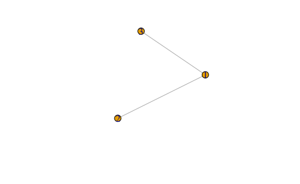

```r
g = make_empty_graph(n=3,directed=FALSE)
g = add_edges(g,c(1,2,1,3))
plot(g)
```

```r
X = as_adjacency_matrix(g,sparse = FALSE)
```

Armamos la matriz de constraints, y el proyector.

```r
Z = generate_state_vector(X)
A = generate_constraint_matrix(X)
P = generate_proyector(A)
print('El vector Z')
```

```
[1] "El vector Z"
```

```r
print(Z)
```

```
[1] "12"  "1n2" "n12" "13"  "1n3" "n13"
```

```r
print('La matriz de constraints')
```

```
[1] "La matriz de constraints"
```

```r
print(A)
```

```
     12 1n2 n12 13 1n3 n13
[1,]  1   1   0 -1  -1   0
```

```r
print('El proyector')
```

```
[1] "El proyector"
```

```r
print(fractions(P))
```

```
     [,1] [,2] [,3] [,4] [,5]
[1,] -1/2    0  1/2  1/2    0
[2,]  5/6    0  1/6  1/6    0
[3,]    0    1    0    0    0
[4,]  1/6    0  5/6 -1/6    0
[5,]  1/6    0 -1/6  5/6    0
[6,]    0    0    0    0    1
```

Definimos los parámetros para las distribuciones de cada link

```r
gamma = 10
kappa_sum = 22
kappas = generate_kappas(Z,gamma = gamma,K=kappa_sum)
print(kappas)
```

```
[1] 10  1  1 10 10  1  1 10
```

```r
params = list('kappas'=kappas,'K'=P)
```

Y ahora lo bueno, definimos los parámetros para la simulación:

```r
z0 = kappas[c(1:3,5:7)]/kappa_sum
initial = t(P)%*%z0
density = density_eta
samples0 = sampling(density = density,initial=initial,params=params,full.result = FALSE,scale=6e-2)
```

Y con esto cargado, podemos explorar un poco los resultados:

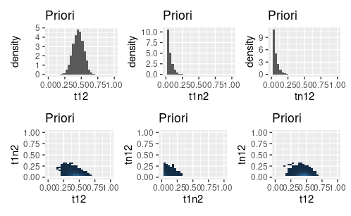

```r
df0 = as.data.frame(t(P%*%t(samples0)))
colnames(df0) = paste('t',Z,sep='')
ggL0 = make_ggmagic(df0)
print(ggL0$gL1)
```

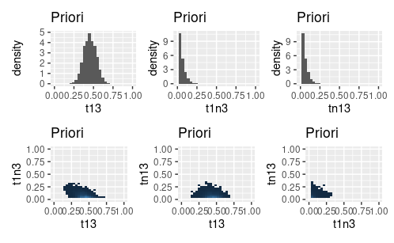

```r
print(ggL0$gL2)
```

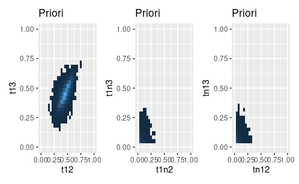

```r
print(ggL0$gL3)
```

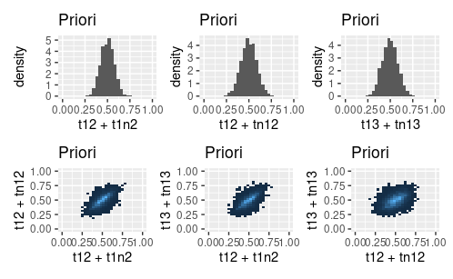

```r
print(ggL0$gL4)
```

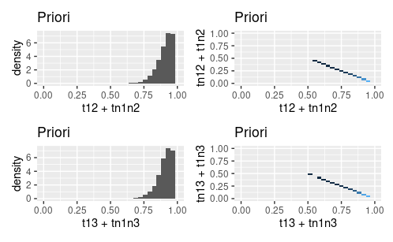

```r
print(ggL0$gL5)
```

#### Ejemplo con los proyectores

Ahora probemos el mismo procedimiento pero para usando las proyecciones.

```r
source('repo.R')
```

Preparamos la red que vamos a usar:

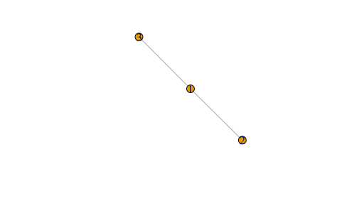

```r
g = make_empty_graph(n=3,directed=FALSE)
g = add_edges(g,c(1,2,1,3))
plot(g)
```

```r
X = as_adjacency_matrix(g,sparse = FALSE)
```

Armamos la matriz de constraints, y el proyector.

```r
Z = generate_state_vector(X)
A = generate_constraint_matrix(X)
P = generate_proyector(A)
print('El vector Z')
```

```
[1] "El vector Z"
```

```r
print(Z)
```

```
[1] "12"  "1n2" "n12" "13"  "1n3" "n13"
```

```r
print('La matriz de constraints')
```

```
[1] "La matriz de constraints"
```

```r
print(A)
```

```
     12 1n2 n12 13 1n3 n13
[1,]  1   1   0 -1  -1   0
```

```r
print('El proyector')
```

```
[1] "El proyector"
```

```r
print(fractions(P))
```

```
     [,1] [,2] [,3] [,4] [,5]
[1,] -1/2    0  1/2  1/2    0
[2,]  5/6    0  1/6  1/6    0
[3,]    0    1    0    0    0
[4,]  1/6    0  5/6 -1/6    0
[5,]  1/6    0 -1/6  5/6    0
[6,]    0    0    0    0    1
```

Definimos los parámetros para las distribuciones de cada link

```r
gamma = 10
kappa_sum = 22
kappas = generate_kappas(Z,gamma = gamma,K=kappa_sum)
print(kappas)
```

```
[1] 10  1  1 10 10  1  1 10
```

```r
params = list('kappas'=kappas,'K'=P)
```

Y ahora lo bueno, definimos los parámetros para la simulación:

```r
initial = kappas[c(1:3,5:7)]/kappa_sum
density = density_comb
samples1 = sampling(density = density,initial=initial,params=params,full.result = FALSE,scale=6e-2)
```

En este caso necesitamos proyectar los resultados muestreados

```r
samples1P = proyect(samples1,P)
```

Exploremos un poco estos resultados

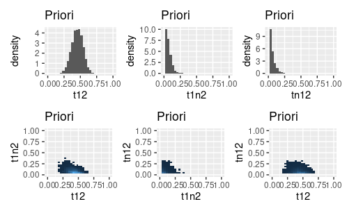

```r
df1 = as.data.frame(samples1P)
colnames(df1) = paste('t',Z,sep='')
ggL1 = make_ggmagic(df1)
print(ggL1$gL1)
```

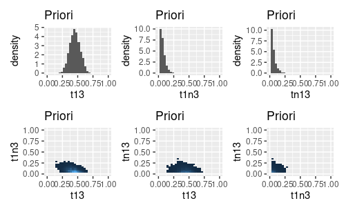

```r
print(ggL1$gL2)
```

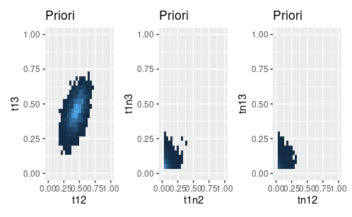

```r
print(ggL1$gL3)
```

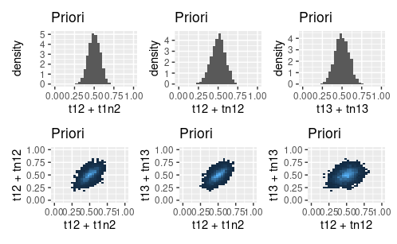

```r
print(ggL1$gL4)
```